# Lab 5, October 1

**Note:** *Lab 5 is not due. I encourage you to complete the lab (bootstrapping is cool and useful!), but you do not have to turn it in. Enjoy fall break!*

**Learning goals:** By the end of this lab, you will be able to

- Use bootstrapping to calculate a p-value with fewer assumptions than parametric hypothesis testing
- Compare bootstrap p-values to parametric p-values

# Setup

**Template file:** lab_05_template.Rmd

**Data:** In this lab, we will look at data from AwesomeGems.com on the price and characteristics of 351 diamonds. The data are contained in the `Diamonds` dataset in the `Stat2Data` package, with information on their total price, price per carat, carat, color, clarity, and depth. The boxplots below visualize the relationship between clarity and price per carat in the `Diamonds` data:

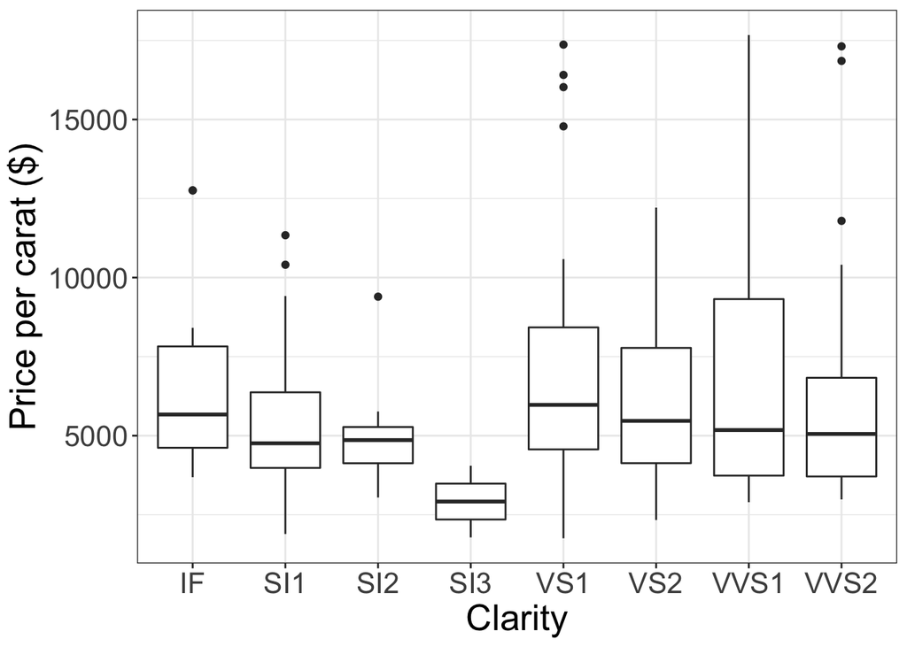

**Research question:** What is the relationship between Clarity and Price per carat for diamonds?

# Model

In alphabetical order, the levels of clarity in the `Diamonds` data are IF (internally flawless), SI1, SI2, SI3 (slightly included), VS1, VS2 (very slightly included), VVS1, VVS2 (very very slightly included). To be consistent with R, we will use this order for our regression model, with IF the baseline and indicator variables IsSI1, IsSI2, IsSI3, IsVS1, IsVS2, IsVVS1, and IsVVS2. Our model is

$\text{Price per carat} = \beta_0 + \beta_1 \ \text{IsSI1} + \beta_2 \ \text{IsSI2} + \beta_3 \ \text{IsSI3} + \beta_4 \ \text{IsVS1} + \beta_5 \ \text{IsVS2} + \beta_6 \ \text{IsVVS1} + \beta_7 \ \text{IsVVS2} + \varepsilon$

# Model fitting

1. Fit the regression model, with clarity as the single categorical predictor and price per carat as the quantitative response. Report the equation of the estimated model.

# Model assumptions

If we check the model assumptions, it looks like the constant variance and normality assumptions are violated.

Residual standard deviation in each group:

| Clarity | residual_std_dev |
| --- | --- |
| IF | 2861.353 |
| SI1 | 2181.669 |
| SI2 | 1677.293 |
| SI3 | 1603.718 |
| VS1 | 2772.494 |
| VS2 | 2518.767 |
| VVS1 | 4304.863 |
| VVS2 | 3481.574 |

QQ plot:

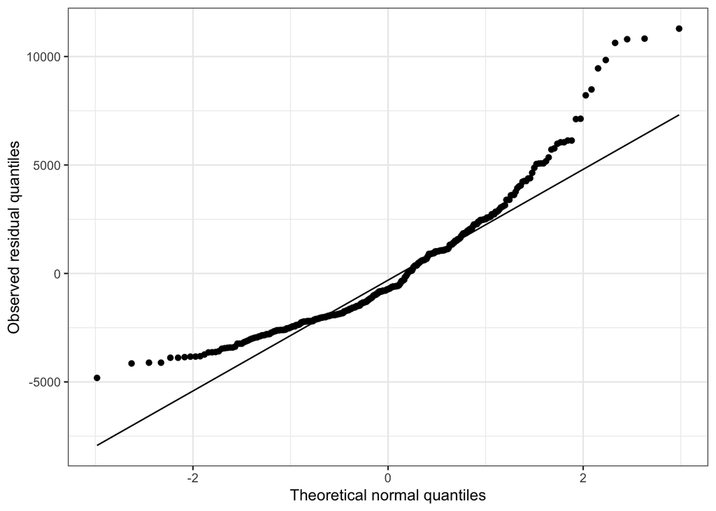

When our model assumptions are violated, statistical inference might no longer be valid. Our question in this lab is, what is the effect of these assumption violations? We will (1) learn how to use the bootstrap to test hypotheses, with fewer assumptions about the distribution of residuals, and (2) compare the bootstrap p-value to the parametric p-value from the F-test.

# Parametric hypothesis testing

We are interested in whether there is a relationship between clarity and price per carat. In the context of our model above, no relationship corresponds to $\beta_1, \beta_2,...,\beta_7 = 0$, so our hypotheses are

$H_0: \beta_1 = \beta_2 = \cdots = \beta_7 = 0$

$H_A: \text{ at least one } \beta_i \neq 0, \ i \in \{1,...,7\}$

2. Use an F-test to test these hypotheses. Report the F-statistic and p-value, and interpret the results in context: is there evidence of a relationship between clarity and price per carat?

# Bootstrap hypothesis testing

## Step 1: Create null data

3. Create a new data frame, `diamonds_null`, by adding a new column called `PricePerCt_null` to `Diamonds`. The `PricePerCt_null` column is defined by $\text{PricePerCt_null}_i = \overline{\text{PricePerCt}} + \text{PricePerCt}_i - \widehat{\text{PricePerCt}}_i$. In other words, `PricePerCt_null` is the average price per carat plus the residuals from our fitted model.

*What’s going on here?*

We want to create data for which the null hypothesis (all levels of clarity have the same mean price per carat) is true. So we make the mean price per carat the same in each group, and use residuals from the fitted model to place points around the mean in each group.

## Step 2: Sample from the null distribution

4. Run the following code to draw a bootstrap sample from `diamonds_null`:

```r
bootstrap_sample <- diamonds_null %>%
  slice_sample(prop = 1, replace = TRUE)
```

*What’s going on here?*

We want to take a bootstrap sample from the null data we created in exercise 3. The `slice_sample` function samples the rows of a data set. `prop = 1` means that the size of the resampled data is the same as the size of the original data; `replace = TRUE` means that rows are sampled with replacement.

## Step 3: Calculate a test statistic

5. Using your `bootstrap_sample` data, fit a regression model with `PricePerCt_null` as the response and `Clarity` as the predictor. Calculate the F-statistic for the fitted model. How does it compare to the F-statistic for the original fitted model (the F-statistic in exercise 2)?

## Step 4: Repeat steps 2 and 3

6. Run your code for exercises 4 and 5 again. You should get different F-statistic. How does it compare to the F-statistic for the original fitted model (the F-statistic in exercise 2)?

*What’s going on here?*

In exercise 4 and 5, we sampled an F statistic from the null distribution of F-statistics (the distribution of the test statistic when $H_0$ is true). We will repeat this process many times to approximate the null distribution.

7. Now we want to repeat steps 2 and 3 *many* times. Doing that by hand would be annoying. Fortunately, we can do it very efficiently in R, using a tool called a *for loop*. Run the following code to create a vector of 5000 bootstrap F-statistics (it may take a couple minutes to run):

```r
bootstrap_f_stats <- c()

for(i in 1:5000){
  bootstrap_sample <- diamonds_null %>%
    slice_sample(prop = 1, replace = TRUE)
  bootstrap_lm <- lm(PricePerCt_null ~ Clarity,
                     data = bootstrap_sample)
  bootstrap_f_stats[i] <- anova(bootstrap_lm)$`F value`[1]
}
```

*What’s going on here?*

A `for` loop is a common programming tool (found in most languages) that lets you repeat a process many times. We begin by creating a vector, `bootstrap_f_stats`, to store our results (`c()` creates an empty vector). Then, we loop: `for(i in 1:5000)` basically means “do the next section of code 5000 times”. For each iteration of the loop, we (1) take a new bootstrap sample from the null distribution, (2) re-fit the model, (3) calculate the test statistic, and (4) store the test statistic in `bootstrap_f_stats`.

## Step 5: calculate a bootstrap p-value

8. Let’s have a look at the distribution of our bootstrap F-statistics. We’ll make a histogram. Since we saved the bootstrap F-statistics in a vector called `bootstrap_f_stats`, it is easier to use the `hist` function in R, rather than convert our data to a nice data frame and use ggplot. Run the code below to make the histogram. How does our F-statistic from exercise 2 (which was F = 1.88) compare to the distribution of bootstrap F-statistics?

```r
hist(bootstrap_f_stats)
```

*What’s going on here?*

So far in this course, we’ve made histograms with `ggplot`. But `ggplot` requires our data to be a dataframe. Here, `bootstrap_f_stats` is just a vector (you can think of this like a list of numbers), not a dataframe. `hist` is a basic R function for making a histogram with a vector; it is not part of the tidyverse, and it behaves differently than ggplot.

9. Finally, we will calculate our p-value. Since our bootstrap F-statistics were calculated from data sampled under the null hypothesis, the bootstrap F-statistics serve as an approximate sample from the null distribution. So our bootstrap p-value is calculated by the fraction of bootstrap F-statistics which are greater than the observed statistic (F = 1.88) from exercise 2:

```r
bootstrap_p_value <- mean(bootstrap_f_stats > 1.88)
```

*What’s going on here?*

Our bootstrap p-value is the fraction of bootstrap F-statistics which are greater than the observed statistic we calculated on the original data. In R, you can calculate proportions with the `mean` function (proportions are just means of 0s and 1s). Note that the bootstrap p-value is an approximate p-value, which will vary slightly each time you calculate it (since you are using only a finite number of bootstrap samples – in this case, 5000).

10. How does the bootstrap p-value from exercise 9 compare to the parametric p-value you calculated in exercise 2?

# Moral

The moral of the story here is that:

- We can sometimes use bootstrapping to calculate p-values, rather than parametric distributions like the F distribution. Bootstrapping generally requires fewer assumptions.
- Even when parametric assumptions are violated, the parametric p-value can sometimes be similar to the bootstrap p-value, and the parametric p-value is much easier to calculate.

So if you’re worried about assumption violations, you can try a bootstrap p-value, but it doesn’t always matter.